# Data analysis and visualization using R

The R toolbox

Michiel Noback

January 2020

# Embarking in Data Science

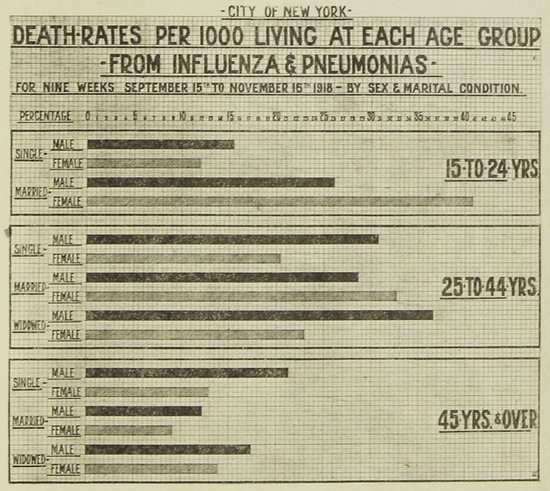

# Why do statistical programming?

# Complete reproducibility and flexibility

- Keeping an exact log of all your mouse clicks in Excel may be problematic…
- Redoing an analysis with adjustments is easy
- Store the analysis, not its output

# The R toolbox

# Overview

This presentation will introduce you to a toolbox that will serve you well during your data quests.

- The R programming language
- The R studio IDE (Integrated Development Environment)
- R Markdown as documenting and reporting tool
- swirl as training environment

# Tool 1: R itself

# The R programming language

Besides its free nature, R is very popular because it

- has an interactive mode (read–evaluate–print loop: REPL)
- makes repeating analyses (with new data) very easy
- supports “literate programming” for creating presentations (such as this one!) and reports
- has embedded advanced graphical support

# R graphics showcase

Below follow some figures that you will be able to make at the end of this smester

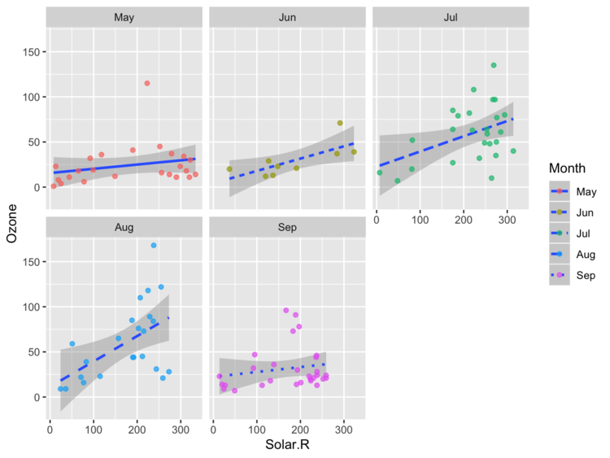

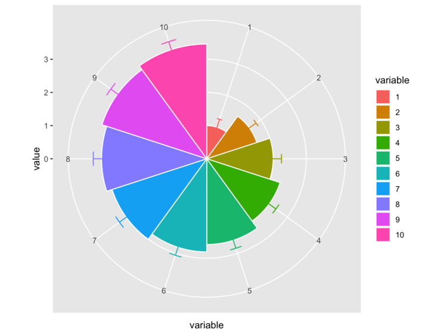

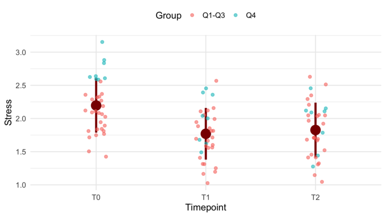

# Tool 2: RStudio

[figure not shown]

RStudio logo

# The workbench

[figure not shown]

# Tool 3: RMarkdown

[figure not shown]

# RMarkdown is a great reporting tool

In RMarkdown, you can combine regular text and figures with embedded R code that will be executed to generate a final document.

You can use it to

- create reports in word, pdf or html (web)
- create presentations (such as this one)
- create entire websites (as the next course shows)

# RMarkdown is really basic

[figure not shown]

RMarkdown

[source http://rmarkdown.rstudio.com/](http://rmarkdown.rstudio.com/)

# Tool 4: swirl

# swirl

- Swirl is a very nice tool to train your R brain
- It is a framework for interactive lessons in R
- I recommend doing those!
- See [swirlstats.com](http://swirlstats.com/)